# Rcupcake: An R package for querying and analyzing EHR data through the BD2K PIC-SURE RESTful API

Alba Gutierrez-Sacristan, Romain Guedj, Gabor Korodi, Jason Stedman, Laura I. Furlong, Chirag J. Patel, Isaac S. Kohane and Paul Avillach

Department of Biomedical Informatics, Harvard Medical School  
Research Programme on Biomedical Informatics (GRIB)

alba_gutierrez@hms.harvard.edu

30 May 2017

#### Package: Rcupcake 0.99.0

# 1 Introduction

The `Rcupcake` package contains functions to query different databases through the BD2K RESTful API, a programmatic interface that provides access to different data sources, making easier data accessibility, analysis reproducibility and scalability. The `Rcupcake` package includes analysis functions to study demographic population, phenotype descriptive analysis, prevalence and co-occurrence, according to patient age, gender and variation status if data available. A special focus is made on visualization of the results, providing a variety of representation formats such as networks, heatmaps and barplots (Table 1).

## 1.1 Background

In the era of big data and precision medicine, the number of databases containing clinical and genomic information is increasing in an exponential way. Enables the experts to focus on their research questions rather than in the computation data merging, access and management is one of the biggest challenges nowadays.

Towards the aim of developing reproducible and scalable analysis, the `Rcupcake` package has been developed. This R package allows to make queries to different databases through the PIC-SURE API, simplifying the data connection and analysis. Moreover it allows to easily reproducible analysis between different databases as well as its integration with other packages available in R to develop bioinformatics analysis workflows.

The tasks that can be performed with `Rcupcake` package are the following:

1. Query through the BD2K PIC-SURE API RESTful API
2. Demographic descriptive analysis based on age and gender
3. Phenotype descriptive analysis taking into account continuous and categorical variables.
4. Phenotype prevalence and co-occurrence analysis according to age, gender and gene variation status if available.
5. Extract those patients that have been diagnosed with a determined pair of phenotypes.

## 1.2 Installation

The package is provided through GitHub. To install the user must type the two following commands in an R session:

```r
library(devtools)
install_github("hms-dbmi/Rcupcake")
```

```r
library(Rcupcake)
```

## 1.3 S4 objects

### 1.3.1 `cupcakeData`

`cupcakeData` object is obtained when `dataframe2cupcake` and `z.score` functions are applied. This object is used as input for `demographicSummary` and `phenotypeSummary` descriptive functions. The `cupcakeData` object contains the table dataset and shows the main characteristic:

- The number of variations (N. Variations)
- The number of phenotype variables (N. Phenotypes)
- The number of patients (N. Patients)

```r
RcupcakeExData
```

```
## Object of class 'cupcakeData'
##  . N. Variations:    1
##  . N. Phenotypes:   4
##  . N. Patients:     41474
```

```r
class( RcupcakeExData )
```

```
## [1] "cupcakeData"
## attr(,"package")
## [1] "Rcupcake"
```

This object comes with a series of functions to allow users to interact with the information retrieved. These functions are `nphenotype`, `nvariation` and `extract`.

The `nphenotype` function returns the phenotypes present in the output of the given query.

```r
nphenotypeExample <- Rcupcake::n.phenotype( RcupcakeExData )
class( nphenotypeExample )
```

```
## [1] "character"
```

```r
nphenotypeExample
```

```
## [1] "Diabetes"    "Arthritis"   "LiverCancer" "AnyCancer"
```

```r
extractExample <- Rcupcake::extract( RcupcakeExData )
class( extractExample )
```

```
## [1] "data.frame"
```

```r
kable( head( extractExample ) )
```

| patient_id | P.Diabetes | P.Arthritis | P.LiverCancer | Gender | P.AnyCancer | Age | M.PCB153 |
| --- | --- | --- | --- | --- | --- | --- | --- |
| 2 | No | No | No | male | No | 85 | NA |
| 3 |  |  |  | female |  | 0 | NA |
| 4 | No | No | No | female | No | 49 | 0.109 |
| 5 | No |  |  | male |  | 18 | NA |
| 6 | No |  |  | female |  | 4 | NA |
| 7 | No | Yes | No | male | No | 31 | NA |

```r
nvariationExample <- Rcupcake::n.variation( RcupcakeExData )
class( nvariationExample )
```

```
## [1] "character"
```

```r
nvariationExample
```

```
## [1] "PCB153"
```

### 1.3.2 `cupcakeResults`

- Minimum age of the patients in the dataset (Age Min)
- Minimum age of the patients in the dataset (Age Max)
- Patients gender
- variation, if selected
- Number of patients in the age and gender interval in the database
- Number of patients in the age and gender interval with the variation select
- The prevalence of the variation in the dataset
- Odds ratio range
- Relative risk range
- Phi value range
- Number of resultant co-occurrences

```r
cupcakeResults
```

```
## Object of class 'cupcakeResults'
##  . Age Min : 0
##  . Age Max : 85
##  . Gender  : ALL
##  . Variation : ALL
##  . Patients in the age and gender interval: 41474
##  . Patients with vairation selected: 41474
##  . Prevalence: 100
##  . Odds ratio range: [0 , Inf]
##  . Relative risk range: [0.002 , 23.067]
##  . Phi range: [-0.914 , 1]
##  . Number of comorbidities: 48
```

```r
class( cupcakeResults )
```

```
## [1] "cupcakeResults"
## attr(,"package")
## [1] "Rcupcake"
```

The `cupcakeResults` object come with the `extract` function. The `extract` function allows the user to retrieve data stored in the object. The `extract` function returns a formatted `data.frame` with the complete set of results obtained from the co-occurrence analysis.

# 2 Retrieve data from the database

The first step in order to perform any analysis is extracting the data related to the patients of interest. The next steps should be followed:

1. Start session
2. Select the variables of interest.
3. Build the JSON query
4. Run the query.

## 2.1 Start session

```r
sessionEx <- start.session(
              url         = "https://nhanes.hms.harvard.edu/",
              apiKey      = "YOURKEY"
              )
sessionEx
```

## 2.2 Select the variables of interest

```r
nhanesPcbs <- get.children(
                 fieldname   = "/nhanes/Demo/laboratory/laboratory/pcbs/",
                 url         = "https://nhanes.hms.harvard.edu/"
              )
head( nhanesPcbs )

[1] "/nhanes/Demo/laboratory/laboratory/pcbs/3,3,4,4,5,5-hxcb (fg%2Fg)/"
[2] "/nhanes/Demo/laboratory/laboratory/pcbs/3,3,4,4,5-pncb (fg%2Fg)/"
[3] "/nhanes/Demo/laboratory/laboratory/pcbs/3,4,4,5-tcb (fg%2Fg)/"
[4] "/nhanes/Demo/laboratory/laboratory/pcbs/PCB101 (ng%2Fg)/"
[5] "/nhanes/Demo/laboratory/laboratory/pcbs/PCB105 (ng%2Fg)/"
[6] "/nhanes/Demo/laboratory/laboratory/pcbs/PCB110 (ng%2Fg)/"
```

## 2.3 Build the JSON query

```r
queryExample <- my.query( myfields = "PCB153",
                          myvector = nhanesPcbs
               )
```

## 2.4 Run the query

```r
query <- my.data(
              query  = system.file("extdata", "jsonQueryNhanes", package="Rcupcake"),
              url    = "https://nhanes.hms.harvard.edu/"
              )
```

# 3 Transform the data in a cupcakeData object

Once the data is in a data.frame format, it has to be transformed into a `cupcakeData` class object. Note that to perform a correct analysis, the data frame should contain:

- 3 demographic variables: patient_id, Gender and Age.
- phenotype variables name should start with a “P”
- variation variables name, if present, should start with a “M”

In order to transform the data.frame into a `cupcakeData` object, the `dataframe2cupcake` function has to be applied. The only input needed is the `input`, that determines the file with the complete path where the required input file is located.

```r
cupcakeExData <- dataframe2cupcake( input = paste0(system.file("extdata", package="Rcupcake"), "/queryOutput.txt"),
                                  verbose = TRUE )
```

```
## Loading the input datasets
```

```
## Checking the inputData file structure
```

```
## Removing duplicated data
```

```
## There are 41474 patients in your input data with complete information for all your variables, from the initial 41474 patients in your list.
```

```
## Checking the number of variations in the inputData file
```

```
## Generating the result object
```

```r
class( cupcakeExData )
```

```
## [1] "cupcakeData"
## attr(,"package")
## [1] "Rcupcake"
```

```r
cupcakeExData
```

```
## Object of class 'cupcakeData'
##  . N. Variations:    1
##  . N. Phenotypes:   4
##  . N. Patients:     41474
```

```r
head( Rcupcake::extract( cupcakeExData ) )
```

```
##   patient_id P.Diabetes P.Arthritis P.LiverCancer Gender P.AnyCancer Age
## 1          2         No          No            No   male          No  85
## 2          3                                      female               0
## 3          4         No          No            No female          No  49
## 4          5         No                             male              18
## 5          6         No                           female               4
## 6          7         No         Yes            No   male          No  31
##   M.PCB153
## 1     <NA>
## 2     <NA>
## 3    0.109
## 4     <NA>
## 5     <NA>
## 6     <NA>
```

# 4 Transform continuous in categorical variables: zscore

Phenotype variables can be continuous or categorical. Co-occurrence analysis will be only applied to those variables that are classified as categorical, like for example, `P.Herpes`, which has `yes` or `no` values. If desired, user can apply the `z.score` function, that given an object of class `cupcakeData`, it transforms continuous into categorical variable applying Z-score. As a result a new `cupcakeData` object is generated.

Note that if the number of individuals is lower than 5000 a Saphiro test [1] will be done to test the normal distribution, otherwise a Kolmogorov-Smirnov test [2] will be performed. The steps followed in this process are the next:

1. Checking is the variable follows a normal distribution
2. If the variable does not follow a normal distribution the Z-score will not be estimated.
3. If the variable follows a normal distribution (p-value of the shapiro or Kolmogorov-Smirnov test is lower than 0.05) then: 3.1. it is checked if there is correlation between the age and the variable. When correlation is observed, it is fitted a linear model.
4. Z-score will be estimated for this variable

As an input `z.score` function requires:

- input: a `cupcakeData` object, obtained with the `dataframe2cupcake` function.
- zscoreCutOff: determines Z-score cut-off to categorize the continuous variable. By default it is set to -2 and 2.
- nfactor: determines the maximum number of values that a variable could have to be defined as categorical. By default it is 10.

```r
zscoreExample <- z.score( input        = cupcakeExData,
                          zscoreCutOff = c( -2, 2 ),
                          nfactor      = 10,
                          verbose      = TRUE )
```

```
## Checking the input object
```

```
## Diabetes phenotype is considered as a categorical variable
```

```
## Z-score will not be applied to Diabetes variable
```

```
## Arthritis phenotype is considered as a categorical variable
```

```
## Z-score will not be applied to Arthritis variable
```

```
## LiverCancer phenotype is considered as a categorical variable
```

```
## Z-score will not be applied to LiverCancer variable
```

```
## AnyCancer phenotype is considered as a categorical variable
```

```
## Z-score will not be applied to AnyCancer variable
```

As a result a new `cupcakeData` object is obtained. Note that the transformation cannot always be done.

```r
head( Rcupcake::extract( cupcakeExData ) )
```

```
##   patient_id P.Diabetes P.Arthritis P.LiverCancer Gender P.AnyCancer Age
## 1          2         No          No            No   male          No  85
## 2          3                                      female               0
## 3          4         No          No            No female          No  49
## 4          5         No                             male              18
## 5          6         No                           female               4
## 6          7         No         Yes            No   male          No  31
##   M.PCB153
## 1     <NA>
## 2     <NA>
## 3    0.109
## 4     <NA>
## 5     <NA>
## 6     <NA>
```

```r
head( Rcupcake::extract( zscoreExample ) )
```

```
##   patient_id P.Diabetes P.Arthritis P.LiverCancer Gender P.AnyCancer Age
## 1          2         No          No            No   male          No  85
## 2          3                                      female               0
## 3          4         No          No            No female          No  49
## 4          5         No                             male              18
## 5          6         No                           female               4
## 6          7         No         Yes            No   male          No  31
##   M.PCB153
## 1     <NA>
## 2     <NA>
## 3    0.109
## 4     <NA>
## 5     <NA>
## 6     <NA>
```

Note that the `z.score` function transform the continuous phenotypes in categorical. In order to transform the variation, if necessary, the user should do it manually. For example, ‘M.PCB153’ variable, can be changed into categorical applying the next code:

```r
cupcakeExData@iresult$M.PCB153 <- ifelse( is.na(cupcakeExData@iresult$M.PCB153), "no", "yes" )
summary(as.factor(cupcakeExData@iresult$M.PCB153))
```

```
##    no   yes
## 35346  6128
```

# 5 Demographic analysis

The `Rcupcake` R package allows the user to analyze and characterize the population under study. To have a general idea about the population main characteristics, the user can apply the `demographic.summary` function.

The function `demographic.summary` describes the demographic characteristics (sex, age) of the population under study. The `demographic.summary` function requires three arguments:

- *input*: the genopheno object.
- *maleCode*: the symbol which denotes males in the table (e.g., 0, M, Male…etc)
- *femaleCode*: the symbol which denotes females in the table (e.g., 1, F, Female…etc)

The `demographic.summary` function output includes:

- A barplot with the age distribution of the whole study population
- A boxplot showing the age distribution by gender.
- A pie chart representing the gender distribution.

```
## Checking the input object
```

```
## Creating a summary table with the main characteristics of population
```

```
## Generating the sex distribution plot
```

```
## Generating the age distribution plot
```

```
## Generating the plot showing age distribution according to gender
```

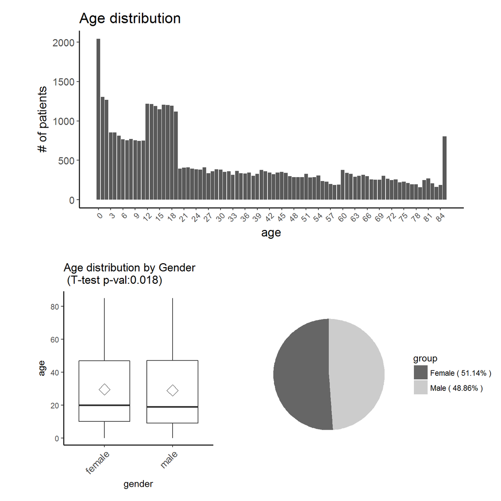

```r
Rcupcake::demographic.summary ( input       = cupcakeExData,
                               maleCode    = "male",
                               femaleCode  ="female",
                               verbose     = TRUE )
```

# 6 Phenotype analysis

The `Rcupcake` R package includes the `phenotype.summary` function that describes the phenotypic characteristics for the whole study population, according to the status regarding one selected variation if genotype information available. otherwise a general summary of the different phenotype values is displayed.

The `phenotype.summary` function requires as input the next arguments:

- input: the `genopheno` object.
- variation: the variation of interest
- nfactor: determines the maximum number of values that a variable could have to be defined as categorical. By default it is 10.
- showTable: the table is displayed before the barplot.
- showFigures: results are visualized in barplot or boxplot, depending on the kind of variable.
- path: define the path where the output file generated will be saved.

The `phenotype.summary` function output could include:

- A barplot for each categorical phenotype variable
- A boxplot for each continuous phenotype variable
- A table if the showTable argument is TRUE

```r
phenotype.summary( input      = cupcakeExData,
                  showTable   = TRUE,
                  showFigures = FALSE)
```

```
## No variation information will be taken into account
```

```
##        phenotype phenotypeValue P_AllPatients     confint yesno
##         Diabetes                         5.44   [5.2-5.7]    NA
## No      Diabetes             No         88.71   [88.4-89]    NA
## Yes     Diabetes            Yes          5.84   [5.6-6.1]    NA
## 1      Arthritis                        51.12 [50.6-51.6]    NA
## No1    Arthritis             No         36.29 [35.8-36.8]    NA
## Yes1   Arthritis            Yes         12.60 [12.3-12.9]    NA
## 2    LiverCancer                        55.40 [54.9-55.9]    NA
## No2  LiverCancer             No         44.57   [44.1-45]    NA
## Yes2 LiverCancer            Yes          0.04     [0-0.1]    NA
## 3      AnyCancer                        51.10 [50.6-51.6]    NA
## No3    AnyCancer             No         44.57   [44.1-45]    NA
## Yes3   AnyCancer            Yes          4.34   [4.1-4.5]    NA
```

# 7 Phenotypes co-occurrence and prevalence using

Having a general overview about the demographics and the phenotypes included in our data, the next step is to perform the phenotype co-occurrence analysis.

The user can estimate the statistically significant co-occurrences by applying the `co.occurrence` function to the `cupcakeData`object previously generated with the `dataframe2cupcake` function.

### 7.0.1 co-occurrence Measurements

The `co.occurrence` identifies all the possible phenotype co-occurrence and quantify them. Five different quantification measures are estimated:  
- Fisher test - co-occurrence score - Relative risk (RR) - Phi value (Pearson’s correlation for binary variables)  
- Odds ratio

##### 7.0.1.0.1 Fisher test

A Fisher exact test for each pair of diseases is performed to assess the null hypothesis of independence between the two diseases. Four groups of patients are defined in order to perform the statistical testing: patients with phenotype A and phenotype B, patients with phenotype A but not phenotype B, patients with phenotype B but not phenotype A and patients without any of the two phenotypes. The Fisher exact test is then applied to estimated the p-value for each pair of diseases. The Benjamini-Hochberg false discovery rate method is applied on the ranked list to correct for multiple testing.

##### 7.0.1.0.2 co-occurrence score

This score is defined in Roque et al. [3] as follows:
$$comorbidity score =log_2 \left( \cfrac{observed + 1}{expected + 1} \right)$$
$$expected = \cfrac{n_{A} n_{B}}{N}$$

where *observed* stands for the number of disease-disease associations (disease A and disease B), and *expected* is estimated based on the occurrence of each disease (number of patients diagnosed with disease A, *nA*, multiplied by the number of patients diagnosed with the comorbid disorder B, *nB* , and divided by the total number of patients, *N*). Since logarithm is applied, a co-occurrence score of 1.0 means that the observed co-occurrences are higher than two fold (approximately) than expected.

#### 7.0.1.1 Relative risk (RR)

The relative risk (RR) expresses the relationship between the rate of prevalence of a phenotype among the patients exposed and those patients that are not exposed to a certain risk factor. Here the risk factor is other phenotype. The RR value moves from 0 to infinite.

- RR = 1: The risk is the same for patients exposed to the factor of risk than for those patients that are not exposed.
- RR > 1: The patients exposed to the factor of risk are more likely to suffer the disease. It is a risk factor.
- RR < 1: The patients exposed to the factor of risk are less likely to suffer the disease. It is a protection factor.

The RR is estimated as the fraction between the number of patients diagnosed with both diseases and random expectation based on disease prevalence [4]. The RR of observing a pair of diseases A and B affecting the same patient is given by:
$$RR_{AB} = \cfrac{C_{AB} N}{P_A P_B}$$

where *CAB* is the number of patients affected by both diseases, *N* is the total number of patients in the population and *PA* and *PB* are the prevalence of diseases A and B.

#### 7.0.1.2 Phi value (Pearsons correlation for binary variables)

Phi value measures the robustness of the co-occurrence association. It can be expressed mathematically as:
$$\phi_{AB} = \cfrac{C_{AB} N - P_{A} P_{B}}{\sqrt{P_{A} P_{B}(N - P_{A})(N - P_{A})}}$$

where *N* is the total number of patients in the population, *PA* i and *PB* are prevalence of phenotypes A and B respectively. *CAB* is the number of patients that have been diagnosed with both phenotypes A and B, and *PA PB* is the random expectation based on disease prevalence. The Pearson correlation coefficient, can take a range of values from +1 to -1. A value of 0 indicates that there is no correlation between the two diseases; a value greater than 0 indicates a positive correlation between the two diseases and a value less than 0 indicates a negative correlation.

#### 7.0.1.3 Odds ratio

The odds ratio represents the increased chance that someone suffering phenotypes A will have the comorbid phenotypes B. It shows the extent to which suffering a phenotypes increases the risk of developing another phenotype. The odds ratio is derived from a comparison of rates of the phenotypes among individuals who do and do not exhibit the factor of interest. A statistically significant odds ratio (significantly different from 1.00 at the .05 level) indicates an appreciable risk associated with a particular factor. For example, an odds ratio of 2.00 indicates a doubled risk of the appearance of the phenotype

** These measures allow the user to quantify the co-occurrence of phenotype pairs compared with the random expectation. The user can select the measure and the cut-off value in order to asses phenotype co-occurrence.**

The `co.occurrence` function requires 6 arguments:

- input: the `cupcakeData` object
- pth: the path where the file with the phenotype values generated previously is located.
- aggregate: if all the possible phenotypes values want to be considered individually, aggregate must be FALSE. otherwise, the phenotype values should be manually completed by the user (column yes/no) and aggregate must be TRUE.
- ageRange: determines what is the age range of interest for performing the analysis.
- gender: determine what is the gender of interest for performing the co-occurrence analysis.
- variation: determine the variation of interest and the value of this variation.

```r
cupcakeResults <- co.occurrence(
              input         = cupcakeExData,
              pth           = system.file("extdata", package="Rcupcake"),
              aggregate    = FALSE,
              ageRange      = c(0,85),
              gender        = "ALL",
              )
```

As a result, a `cupcakeResults` object is obtained. This object contains a summary of the phenotype co-occurrences that have been found.

```r
class( cupcakeResults )
```

```
## [1] "cupcakeResults"
## attr(,"package")
## [1] "Rcupcake"
```

```r
cupcakeResults
```

```
## Object of class 'cupcakeResults'
##  . Age Min : 0
##  . Age Max : 85
##  . Gender  : ALL
##  . Variation : ALL
##  . Patients in the age and gender interval: 41474
##  . Patients with vairation selected: 41474
##  . Prevalence: 100
##  . Odds ratio range: [0 , Inf]
##  . Relative risk range: [0.002 , 23.067]
##  . Phi range: [-0.914 , 1]
##  . Number of comorbidities: 48
```

## 7.1 Prevalence

The function `pheno.prevalence` displays in a data frame: * Phenotype * Number of patients (N_patients) * Prevalence * Confidence interval

```r
prevalence <- pheno.prevalence( input = cupcakeResults )

kable( prevalence, row.names = FALSE)
```

| phenotype | N_patients | Prevalence(%) | ConfidenceInterval |
| --- | --- | --- | --- |
| Diabetes: No | 36793 | 88.71 | [88.4-89] |
| LiverCancer: / | 22975 | 55.40 | [54.9-55.9] |
| Arthritis: / | 21200 | 51.12 | [50.6-51.6] |
| AnyCancer: / | 21192 | 51.10 | [50.6-51.6] |
| AnyCancer: No | 18484 | 44.57 | [44.1-45] |
| LiverCancer: No | 18484 | 44.57 | [44.1-45] |
| Arthritis: No | 15049 | 36.29 | [35.8-36.8] |
| Arthritis: Yes | 5225 | 12.60 | [12.3-12.9] |
| Diabetes: Yes | 2423 | 5.84 | [5.6-6.1] |
| Diabetes: / | 2258 | 5.44 | [5.2-5.7] |
| AnyCancer: Yes | 1798 | 4.34 | [4.1-4.5] |
| LiverCancer: Yes | 15 | 0.04 | [0-0.1] |

## 7.2 Plotting the co-occurrence results

`Rcupcake` offers several options to visualize the results from the phenotype co-occurrence analysis, in networks and heatmaps.

### 7.2.1 Network

By applying the `cooc.network` function. A network showing the phenotypes co-occurrences is obtained. By default `Rcupcake` package shows a network with `layout.fruchterman.reingold` layout where the phenotypes are joined according to the number of patients that have both phenotypes ( selectValue = patientsPhenoAB). The user can change this value to the different co-occurrence measures - fisher, oddsRatio, relativeRisk, phi, expect, score, fdr, PercentagePhenoAB- that are estimated for each pair of phenotypes.

The `cooc.network` function requires 3 arguments as input:

- input: the `cupcakeResults` object
- representedVariable: the co-occurrence measurement
- variableCutOff: the numeral value of the cutOff

The `cooc.network` function output is a network. Node size is proportional to the phenotype prevalence. Edge numbers represent the selected value.

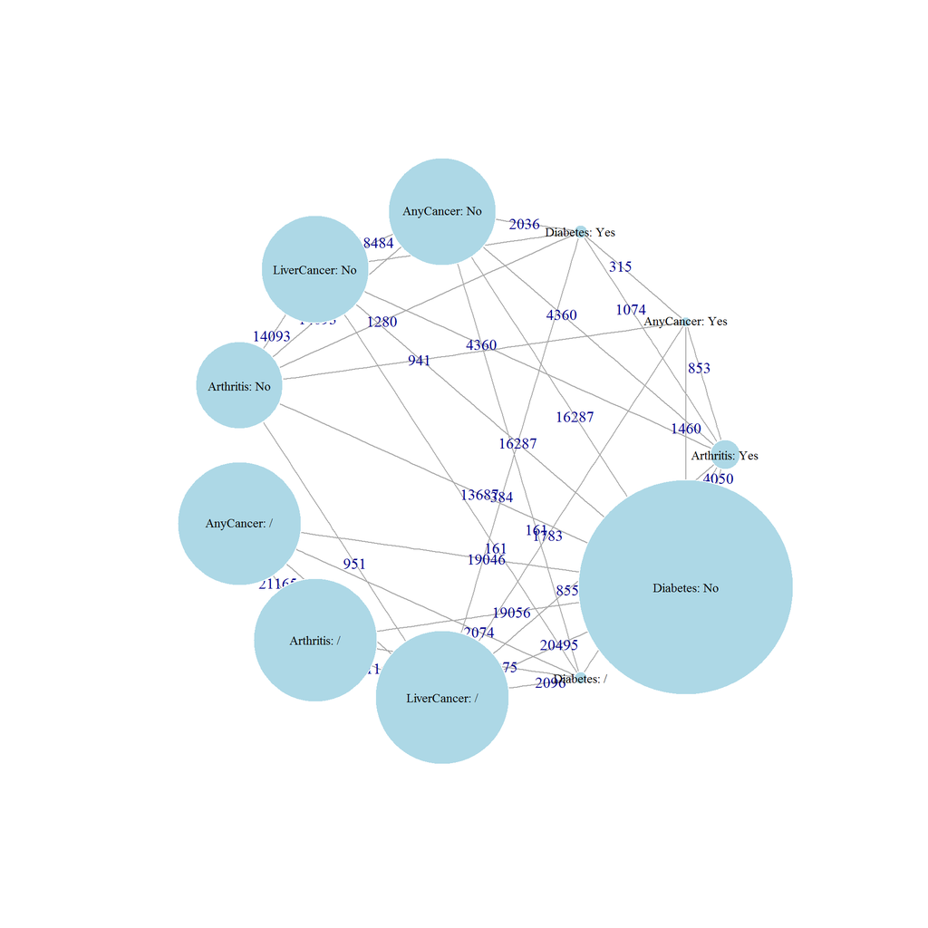

```r
cooc.network ( input               = cupcakeResults,
               representedVariable = "patientsPhenoAB",
               variableCutOff      = 100)
```

### 7.2.2 Heatmap

By applying the `cooc.heatmap` function, a heatmap is displayed. This function is homologous to the `genophenoNetwork` one. The heatmap represents the selected value that by default will be `patientsPhenoAB`. The user can change this value to the different co-occurrence measures - fisher, oddsRatio, relativeRisk, phi, expect, score, fdr, PercentagePhenoAB- that are estimated for each pair of phenotypes.

The `cooc.heatmap` function requires 3 arguments:

- input: the `cupcakeResults` object
- representedVariable: the co-occurrence measurement
- variableCutOff: the numeral value of the cutOff

The `cooc.heatmap` function output is a heatmap. Blue color represents the lower values, red color represents the upper values. The co-occurrence measurement value is showed in each cell.

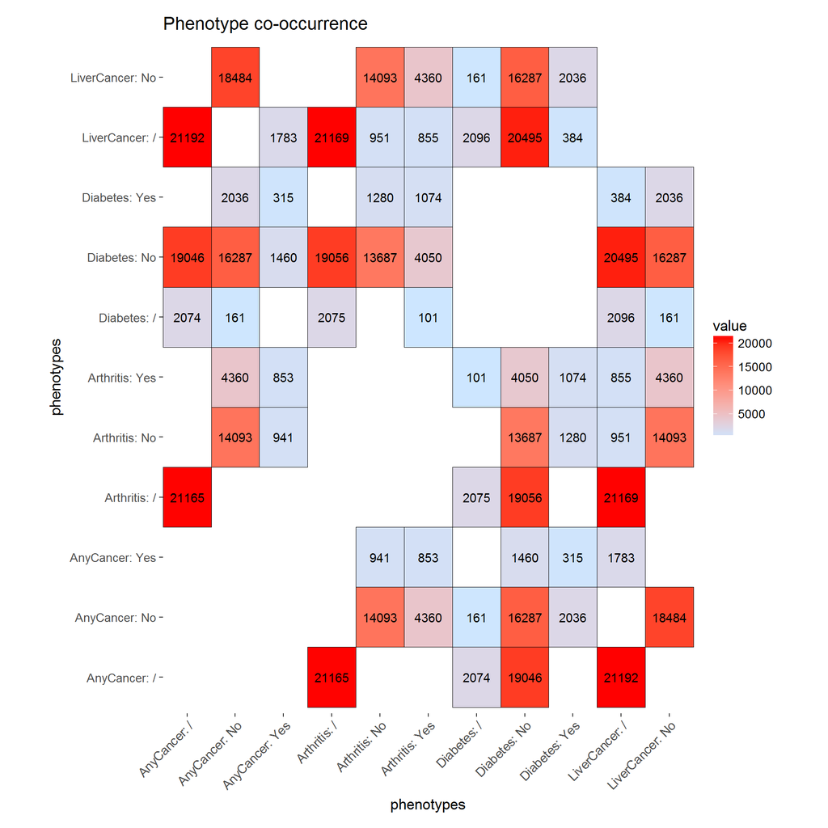

```r
cooc.heatmap ( input               = cupcakeResults,
               representedVariable = "patientsPhenoAB",
               variableCutOff      = 100)
```

## 7.3 Plotting the prevalence results

```
## Checking the input object
```

```
## The network contains 13 nodes and 12 edges.
```

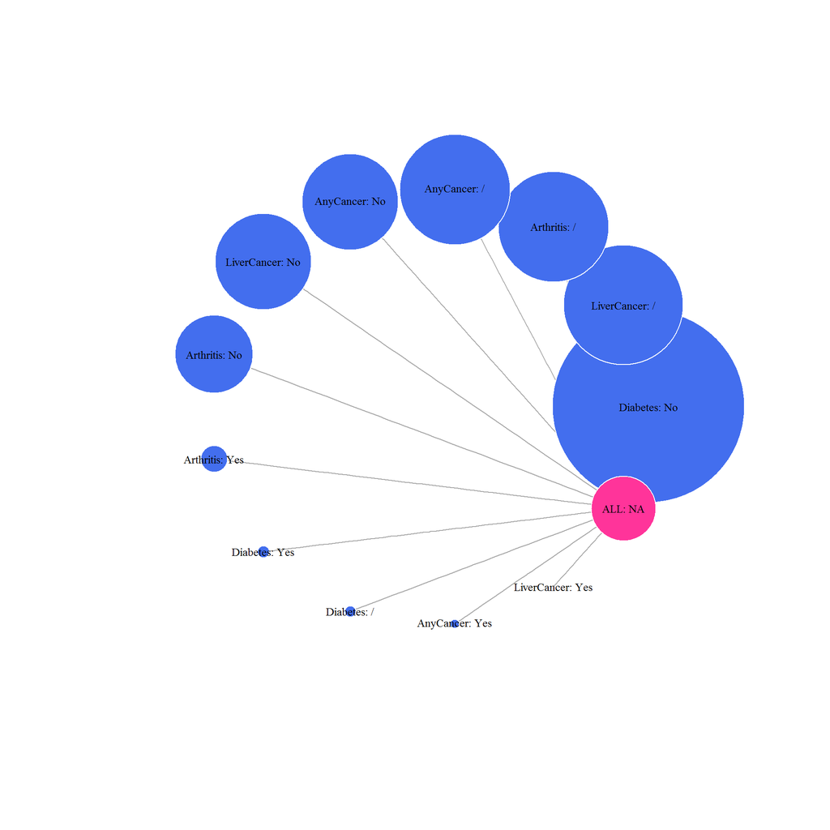

```r
prevalence.plot( input   = cupcakeResults,
                 variation = "PCB153",
                   verbose = TRUE
              )
```

If no variation is indicated, the output of the `prevalence.plot` will be a barplot showing the general prevalence of each phenotype in the data set.

```
## Checking the input object
```

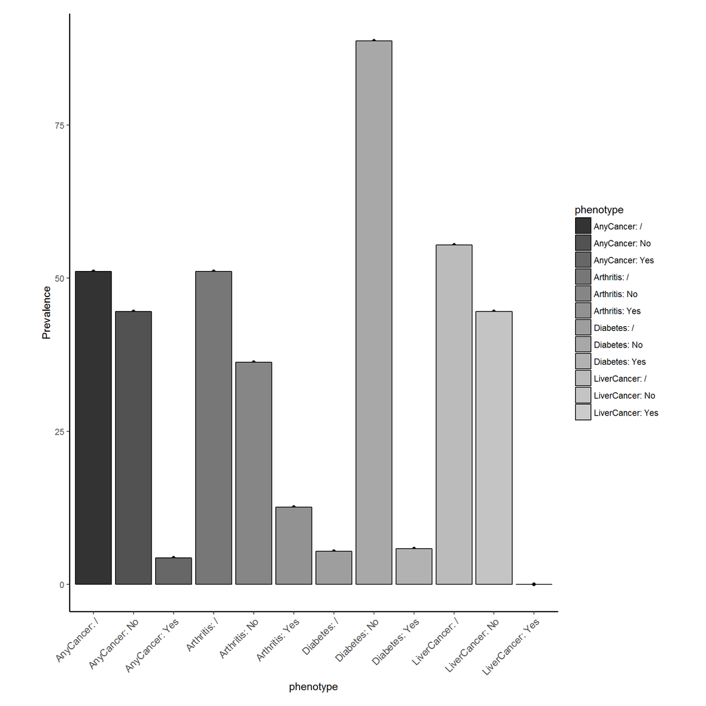

```r
prevalence.plot( input   = cupcakeResults,
                   verbose = TRUE
              )
```

# 8 Summary of `Rcupcake` functions available

Table 1: Functions in `Rcupcake` R package

| Input Object | `Rcupcake` function | Output Generated |
| --- | --- | --- |
| - | `my.data` | Given an url, a key and a JSON object, it generates a data.frame object with the output of the query |
| - | `dataframe2cupcake` | Given a tabulated file, checks if it contains the data in the correct format and generates a `cupcakeData` objec |
| `cupcakeData` | `demographic.summary` | 3 plots: age and gender distribution, relation between age and gender distribution |
|  | `phenotype.summary` | A data.frame with the prevalence of each phenotype according to the value it takes, is retrieved. A figure showing the results can be also obtained. |
|  | `extract` | It generates a data.frame containing the raw data from a query |
|  | `z.score` | It transforms continuous into categorical variable applying Z-score |
|  | `co.occurrence` | It generates a cupcakeResults object |
|  | `patient.selection` | It retrieves a list of patients suffering two phenotypes of interest |
|  | `n.variation` | It retrieves the variations of your data |
|  | `n.phenotype` | It retrieves the phenotypes of your data |
| cupcakeResults | `cooc.heatmap` | It generates a heatmap showing the co-occurrence analysis results |
|  | `cooc.network` | It generates a network showing the co-occurrence analysis results |
|  | `extract` | It generates a data.frame containing the co-occurrence results |
|  | `pheno.prevalence` | It generates a data.frame containing the prevalence of each phenotype |
|  | `prevalence.plot` | It generates a barplot or a network showing the results of the phenotype’s prevalence |

# Bibliography

1. Shapiro SS, Wilk MB. An analysis of variance test for normality (complete samples). Biometrika. 1965;52:591–611.

2. Razali NM, Wah YB, others. Power comparisons of shapiro-wilk, kolmogorov-smirnov, lilliefors and anderson-darling tests. Journal of statistical modeling and analytics. 2011;2:21–33.

3. Roque FS, Jensen PB, Schmock H, Dalgaard M, Andreatta M, Hansen T, et al. Using electronic patient records to discover disease correlations and stratify patient cohorts. PLoS Comput Biol. 2011;7:e1002141. http://journals.plos.org/ploscompbiol/article?id=10.1371/journal.pcbi.1002141.

4. Hidalgo CA, Blumm N, Barabási A-L, Christakis NA. A dynamic network approach for the study of human phenotypes. PLoS computational biology. 2009;5:e1000353. https://www.ncbi.nlm.nih.gov/pmc/articles/PMC2661364/.